# Lab 3, CP 1: Inferência via ICs

Caio Oliveira

May 16, 2018

# INTRODUÇÃO

Nesse laboratório o objetivo era utilizar os dados do Wikimedia para resolver a mesma série de perguntas do [laboratório anterior](http://rpubs.com/Caio-batista/lab2cp4), mas dessa vez se utilizando de **reamostragem** e **intervalos de confiança**. Nesse laboratório, apesar de ter a mesma quantidade de perguntas do outro laboratório mencionado, a última questão é diferente, e se baseia em um teste A/A e não A/B.

Para cada uma das perguntas é explicada como foi feita a reamostragem e como podemos entender a visualização dos dados para assim ter a resposta.

Neste setup além de carregar os dados e as bibliotecas da linguagem que serão necessárias, também é definida aqui a função Mode, que simula a métrica Moda, que vai ser muito útil durante todas as respostas para sumarização.

# Primeira pergunta

### *What is our daily overall clickthrough rate? How does it vary between the groups?*

Para calcularmos o valor da relação (rate) em questão, precisamos antes verificar como se comportam os dados no geral e no grupo particular, que são aquelas sessões que tiveram **num_clicks** > 0.

Aqui fazemos o mesmo método do laboratório anterior para a sumarização dos dados e o cálculo dessa relação. E reafirmamos, a diferença nítida nos valores dessa relação para os grupos A e B. Sendo a relação em A bem maior e mais concentrada que em B.

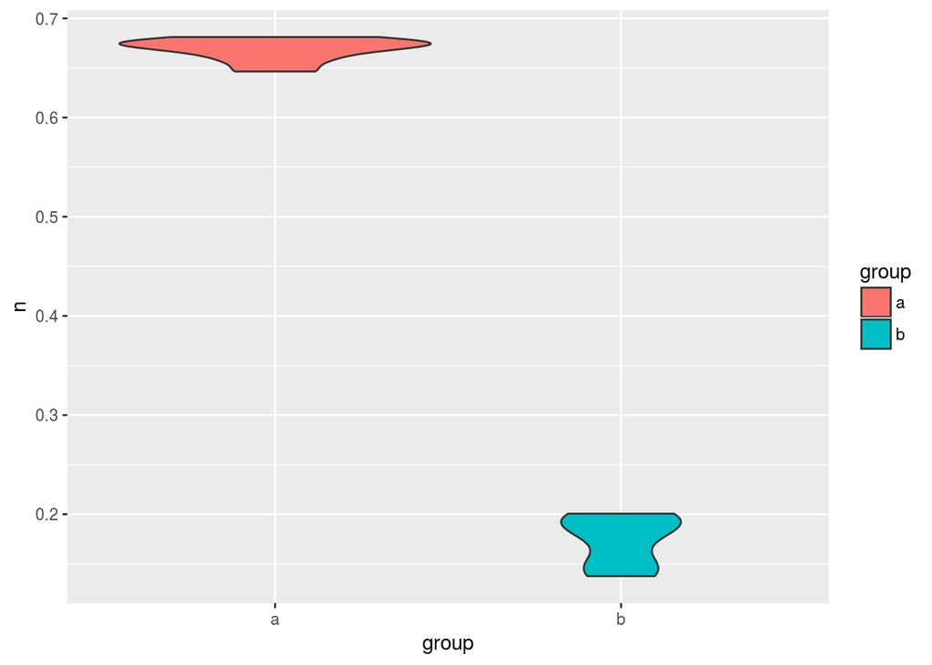

```r
data_grouped_day_1 <- amostra %>%
    mutate(date = as.character.Date(floor_date(session_start_date, unit='day'))) %>%
    group_by(session_id) %>%
    summarise(
      group = Mode(group),
      date = last(date)
    ) %>%
    group_by(date, group) %>%
    count(date, group)

data_grouped_day_2 <- dados %>%
    filter(num_clicks > 0) %>%
    mutate(date = floor_date(session_start_date, unit='day')) %>%
    group_by(session_id) %>%
    summarise(
      group = Mode(group),
      date = last(date)
    ) %>%
    group_by(date, group) %>%
   count(date, group)

data_ratio <- data.frame(data_grouped_day_1$date, data_grouped_day_1$group, data_grouped_day_2$n / data_grouped_day_1$n )
data_ratio <- na.omit(data_ratio)
x <- c("date", "group", "n")
colnames(data_ratio) <- x
ggplot(data_ratio, aes(x = group, y = n, fill = group)) + geom_violin()
```

Para esse caso usaremos uma biblioteca chamada **boot** (Bootstrap) que faz resample dos dados para amostras.

No nosso caso para responder a pergunta, usaremos 1000 repetições da amostra diferentes, com 3 tipos de cálculo para o intervalo de confiança. São eles: **basic, bca** e **perc**.

A seguir estão plotados os gráficos referentes a reamostragem, sua distribuição bem como a correção entre os fatores. Para esse caso, na função de reamostragem, utilizamos a mediana e não a média, por causa dos valores extremos que existem, principalmente no grupo A.

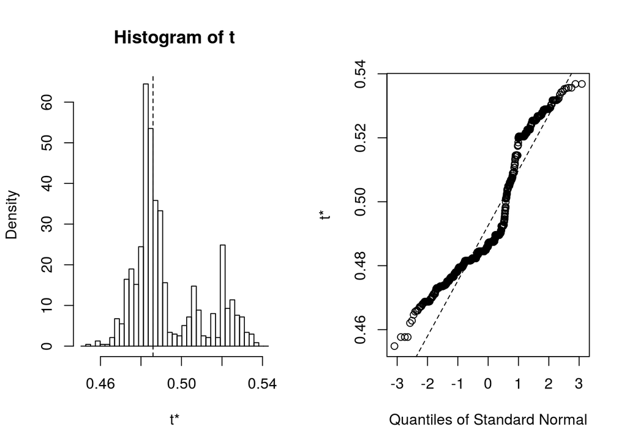

```r
func.boot<- function(dado, indices){
    d = dado %>%
      slice(indices) %>%
      group_by(group) %>%
      summarise(median_group = median(n)) %>%
      pull(median_group)

    return(d[1] - d[2])
}
res.boot <- boot(data = data_ratio,
                 statistic = func.boot,
                 R = 1000)
plot(res.boot)
```

```r
boot.ci(boot.out = res.boot, conf = 0.95, type = "basic")
```

```
## BOOTSTRAP CONFIDENCE INTERVAL CALCULATIONS
## Based on 1000 bootstrap replicates
##
## CALL :
## boot.ci(boot.out = res.boot, conf = 0.95, type = "basic")
##
## Intervals :
## Level      Basic
## 95%   ( 0.4430,  0.5031 )
## Calculations and Intervals on Original Scale
```

```r
boot.ci(boot.out = res.boot, conf = 0.95, type = "bca")
```

```
## BOOTSTRAP CONFIDENCE INTERVAL CALCULATIONS
## Based on 1000 bootstrap replicates
##
## CALL :
## boot.ci(boot.out = res.boot, conf = 0.95, type = "bca")
##
## Intervals :
## Level       BCa
## 95%   ( 0.4688,  0.5289 )
## Calculations and Intervals on Original Scale
```

```r
boot.ci(boot.out = res.boot, conf = 0.95, type = "perc")
```

```
## BOOTSTRAP CONFIDENCE INTERVAL CALCULATIONS
## Based on 1000 bootstrap replicates
##
## CALL :
## boot.ci(boot.out = res.boot, conf = 0.95, type = "perc")
##
## Intervals :
## Level     Percentile
## 95%   ( 0.4688,  0.5289 )
## Calculations and Intervals on Original Scale
```

# Segunda pergunta

### *Which results do people tend to try first? How does it change day-to-day?*

Essa pergunta não pode ser respondida com todos os dados que temos, pois como analisamos no outro laboratório, a mediana e a moda desses dados, para o **first_click**, é majoritariamente 1, e o estudo interessante a se fazer é do pior caso. Ou dos piores **n** casos.

Então primeiramente aqui mostramos os dados filtrados, depois nossa análise dos grupos e por fim, a análise durante o tempo.

```r
results <- dados %>%
    mutate(day = floor_date(session_start_date, unit='day')) %>%
    filter(first_click != 'NA')

nrow(results)
```

```
## [1] 33194
```

```r
results <- results %>%
    arrange(first_click) %>%
    group_by(group) %>%
    top_n(n = 500, wt = first_click)
```

A escolha para essa pergunta foi selecionar os top 500 **first_click**, de cada grupo. E a partir dessa amostra, fazer uma reamostragem utilizando o **bootstrap**. Podemos perceber que os dados no gráfico de distribuição se concentram abaixo de 50 do eixo Y, apesar da grande dispersão do grupo A.

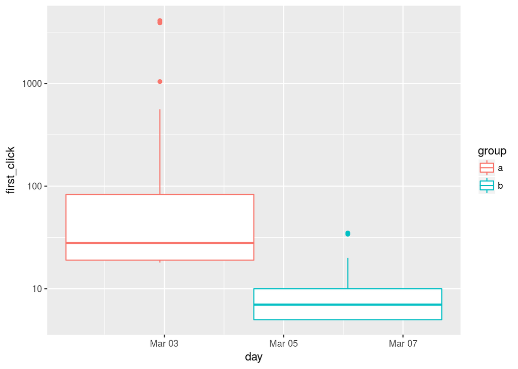

```r
results %>%
    ggplot(aes(x = day, y = first_click, color = group, group = group)) +
    geom_boxplot() +
    theme(plot.title = element_text(hjust = 0.5)) + scale_y_log10()
```

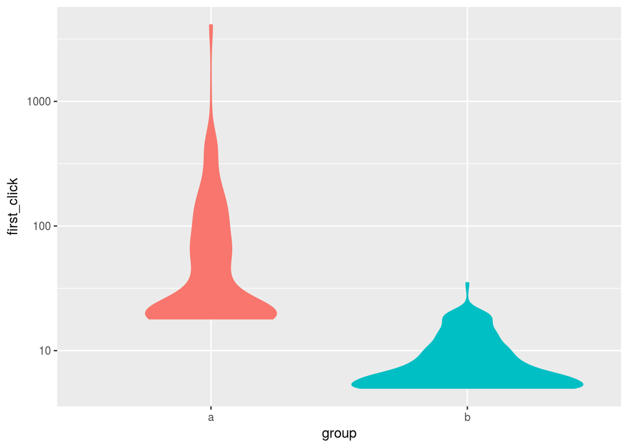

```r
results %>%
    ggplot(aes(x= group,
               y = first_click,
               color= group, fill = group)) +
    geom_violin() +
    theme(plot.title = element_text(hjust = 0.5), legend.position="none") + scale_y_log10()
```

Fazendo a reamostragem temos a mesma semelhança nos resultados acima apresentados, nos dois gráficos. Os valores ficam entre 16 e 26 em seus extremos, com 95% de confiança. Vale ressaltar que a métrica aqui, como na questão anterior também foi a mediana e não a média.

```r
func.boot <- function(dado, indices){
    dado <- dado %>%
      slice(indices) %>%
      group_by(group) %>%
      summarise(median_group = median(first_click)) %>%
      pull(median_group)

    return(dado[1] - dado[2])
}

res.boot <- boot(data = results,
                   statistic = func.boot,
                   R = 2000)

boot.ci(res.boot, conf = 0.95, type = "basic")
```

```
## BOOTSTRAP CONFIDENCE INTERVAL CALCULATIONS
## Based on 2000 bootstrap replicates
##
## CALL :
## boot.ci(boot.out = res.boot, conf = 0.95, type = "basic")
##
## Intervals :
## Level      Basic
## 95%   (16, 25 )
## Calculations and Intervals on Original Scale
```

```r
boot.ci(res.boot, conf = 0.95, type = "perc")
```

```
## BOOTSTRAP CONFIDENCE INTERVAL CALCULATIONS
## Based on 2000 bootstrap replicates
##
## CALL :
## boot.ci(boot.out = res.boot, conf = 0.95, type = "perc")
##
## Intervals :
## Level     Percentile
## 95%   (17, 26 )
## Calculations and Intervals on Original Scale
```

```r
boot.ci(res.boot, conf = 0.95, type = "bca")
```

```
## BOOTSTRAP CONFIDENCE INTERVAL CALCULATIONS
## Based on 2000 bootstrap replicates
##
## CALL :
## boot.ci(boot.out = res.boot, conf = 0.95, type = "bca")
##
## Intervals :
## Level       BCa
## 95%   (15.72, 24.00 )
## Calculations and Intervals on Original Scale
## Some BCa intervals may be unstable
```

Aqui é a construção da resposta, primeiro a sumarização dos dados que foi usado na visualização a seguir e depois, a melhor forma de visualizar os intervalos de confiança para cada um dos grupos e por dia.

```r
df2 <- summarySE(results, measurevar="first_click",
                    groupvars=c("day", "group"), na.rm = TRUE, conf.interval=.95)

df2$day <- as.factor(df2$day)
df2
```

```
##           day group   N first_click          sd          se          ci
## 1  2016-03-01     a  60  361.850000 1107.294517 142.9511074 286.0445052
## 2  2016-03-01     b  42    8.238095    4.298664   0.6632983   1.3395580
## 3  2016-03-02     a  47   37.531915   60.295955   8.7950690  17.7035557
## 4  2016-03-02     b  60    7.966667    3.631158   0.4687805   0.9380277
## 5  2016-03-03     a  95   49.968421   52.710662   5.4079998  10.7377104
## 6  2016-03-03     b  62    8.096774    4.151672   0.5272629   1.0543273
## 7  2016-03-04     a 131  170.099237  149.924230  13.0989408  25.9146878
## 8  2016-03-04     b  71    8.605634    5.260307   0.6242835   1.2450942
## 9  2016-03-05     a  32   26.812500   16.241002   2.8710307   5.8555058
## 10 2016-03-05     b  63    9.460317    5.189398   0.6538027   1.3069330
## 11 2016-03-06     a  40   58.400000  162.522077  25.6969967  51.9770820
## 12 2016-03-06     b  52    8.000000    4.111199   0.5701208   1.1445652
## 13 2016-03-07     a  66   45.757576   50.565741   6.2242125  12.4306107
## 14 2016-03-07     b  93    8.645161    4.190167   0.4345001   0.8629548
## 15 2016-03-08     a  67   54.522388   43.326232   5.2931417  10.5680983
## 16 2016-03-08     b  81    8.456790    3.748498   0.4164997   0.8288609
```

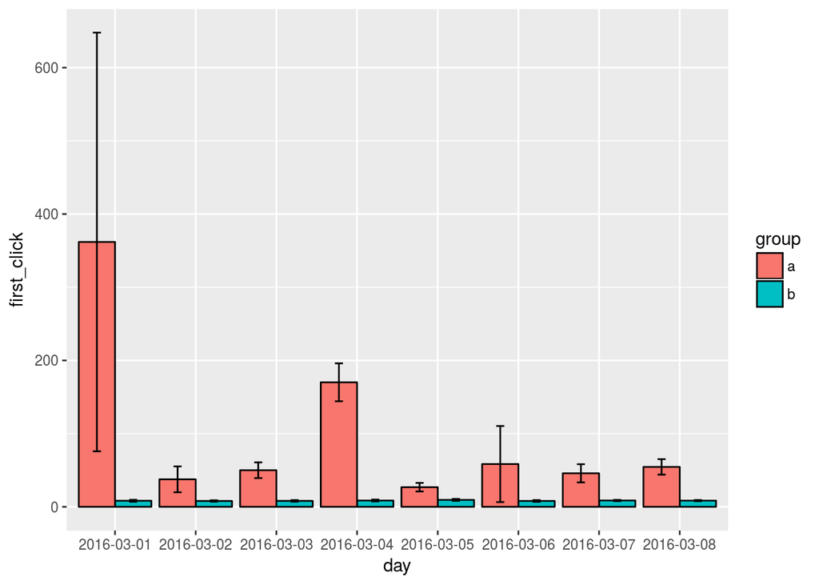

```r
p<- ggplot(df2, aes(x=day, y=first_click, fill=group)) +
  geom_bar(stat="identity", color="black",
           position=position_dodge()) +
  geom_errorbar(aes(ymin=first_click-ci, ymax=first_click+ci), width=.2,
                 position=position_dodge(.9))
print(p)
```

Já podemos perceber a tendência de valores maiores para o grupo A. Entretanto os intervalos de confiança do grupo B não se destacam nessa escala. Se reduzirmos para log 10 podemos visualizar melhor e responder com mais precisão.

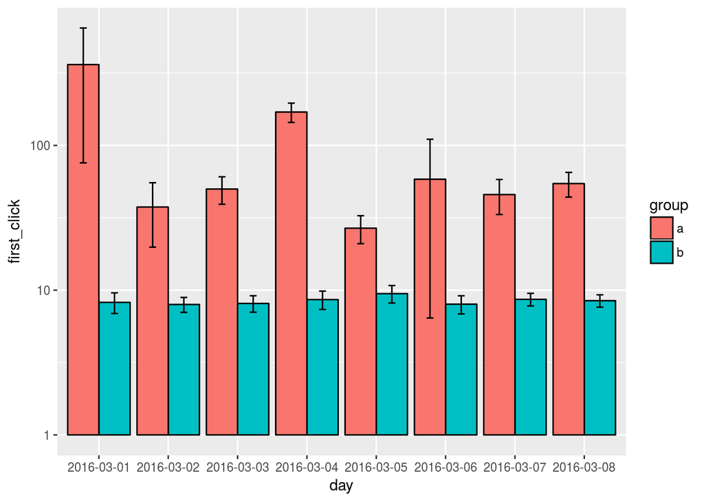

```r
print(p + scale_y_log10())
```

# Terceira pergunta

### *What is our daily overall zero results rate? How does it vary between the groups?*

A terceira pergunta é bastante semelhante a primeira, e de forma análoga ao outro laboratório, calcularemos a relação (*overall zero*) da mesma forma.

A parte da reamostragem será feita da mesma forma que para a questão 1, inclusive utilizando as mesmas formas de cálculo do intervalo de confiança, e a mediana como forma de sumarização.

Podemos ver que nesse caso os valores são bem menores que na relação da primeira questão. Inclusive os intervalos de confiança da métrica.

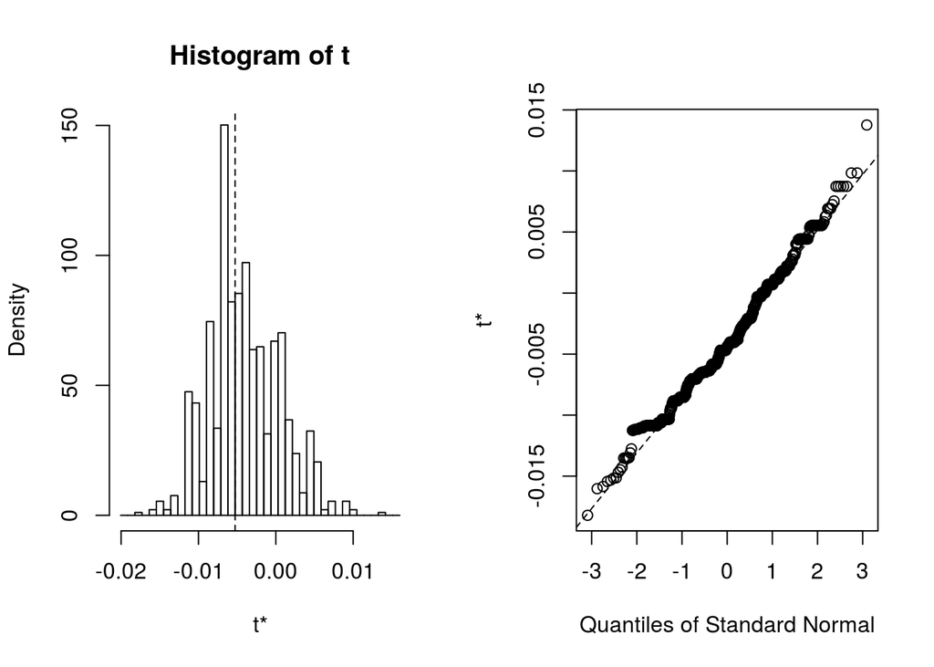

```r
data_grouped_results_0 <- dados %>%
    filter(results == 0) %>%
    mutate(date = floor_date(session_start_date, unit='day')) %>%
    select(date, group) %>%
    group_by(date, group) %>%
    count(date, group)

data_grouped_results_total <- dados  %>%
    mutate(date = floor_date(session_start_date, unit='day')) %>%
    select(date, group) %>%
    group_by(date, group) %>%
    count(date, group)


data_ratio <- data.frame(data_grouped_results_0$date, data_grouped_results_0$group, data_grouped_results_0$n / data_grouped_results_total$n )
data_ratio <- na.omit(data_ratio)
x <- c("date", "group", "ratio")
colnames(data_ratio) <- x


func.boot <- function(dado, indices){
    d <- dado %>%
      slice(indices) %>%
      group_by(group) %>%
      summarise(median_group = median(ratio)) %>%
      pull(median_group)

    return(d[1] - d[2])
}


res.boot <- boot(data = data_ratio,
                 statistic = func.boot,
                 R = 1000)
plot(res.boot)
```

```r
boot.ci(boot.out = res.boot, conf = 0.95, type = "basic")
```

```
## BOOTSTRAP CONFIDENCE INTERVAL CALCULATIONS
## Based on 1000 bootstrap replicates
##
## CALL :
## boot.ci(boot.out = res.boot, conf = 0.95, type = "basic")
##
## Intervals :
## Level      Basic
## 95%   (-0.0161,  0.0006 )
## Calculations and Intervals on Original Scale
```

```r
boot.ci(boot.out = res.boot, conf = 0.95, type = "bca")
```

```
## BOOTSTRAP CONFIDENCE INTERVAL CALCULATIONS
## Based on 1000 bootstrap replicates
##
## CALL :
## boot.ci(boot.out = res.boot, conf = 0.95, type = "bca")
##
## Intervals :
## Level       BCa
## 95%   (-0.0137,  0.0044 )
## Calculations and Intervals on Original Scale
```

```r
boot.ci(boot.out = res.boot, conf = 0.95, type = "perc")
```

```
## BOOTSTRAP CONFIDENCE INTERVAL CALCULATIONS
## Based on 1000 bootstrap replicates
##
## CALL :
## boot.ci(boot.out = res.boot, conf = 0.95, type = "perc")
##
## Intervals :
## Level     Percentile
## 95%   (-0.0111,  0.0055 )
## Calculations and Intervals on Original Scale
```

Da mesma forma que na questão anterior, podemos usar as **error bars** para visualizar o intervalo de confiança de cada grupo. Além da tabela de sumarização dos dados.

```r
df3 <- summarySE(data_ratio, measurevar="ratio",
                    groupvars=c("group"), na.rm = TRUE, conf.interval=.95)

df3$group <- as.factor(df3$group)
df3
```

```
##   group N     ratio          sd          se          ci
## 1     a 8 0.1831291 0.008401262 0.002970295 0.007023631
## 2     b 8 0.1865177 0.006523024 0.002306237 0.005453384
```

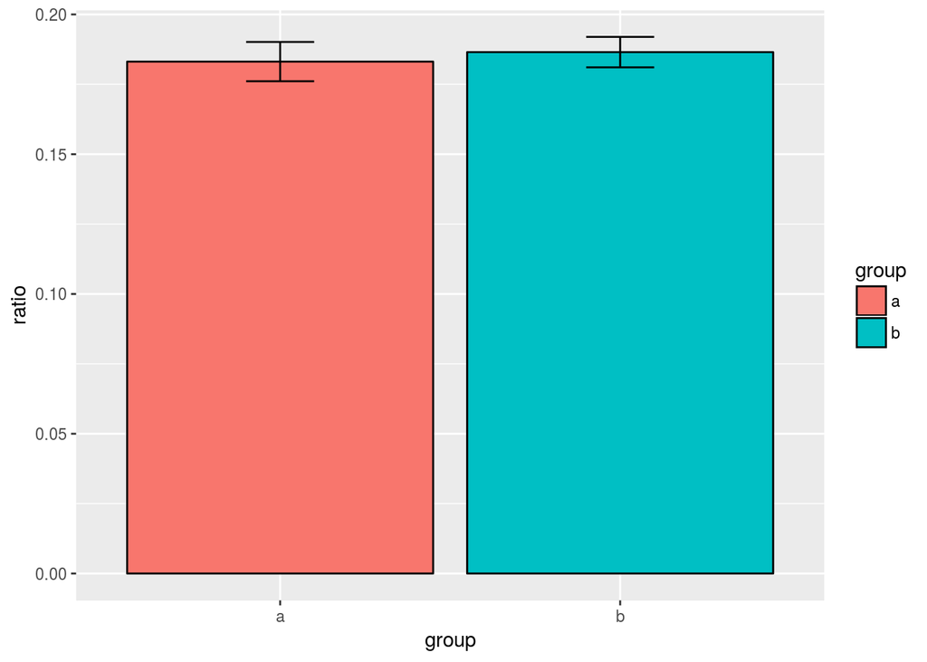

```r
p<- ggplot(df3, aes(x=group, y=ratio, fill=group)) +
  geom_bar(stat="identity", color="black",
           position=position_dodge()) +
  geom_errorbar(aes(ymin=ratio-ci, ymax=ratio+ci), width=.2,
                 position=position_dodge(.9))
print(p)
```

# Quarta pergunta

### *o que acontece se para a pergunta 1, em vez de comparar o grupo A com o grupo B (um teste A/B), você compara metade das sessões do grupo A (escolhida aleatoriamente) com outra metade das sessões do mesmo grupo (um teste A/A)?*

Para responder essa pergunta faremos um pouco diferente da resposta da primeira pergunta, mas com o mesmo intuito de calcular o intervalo de confiança.

Primeiramente retiraremos dois sample dos dados e chamaremos de a1 e a2.

Logo a seguir temos um **violin plot** mostrando a distribuição dos dados. Que não são identicos mas muito parecidos.

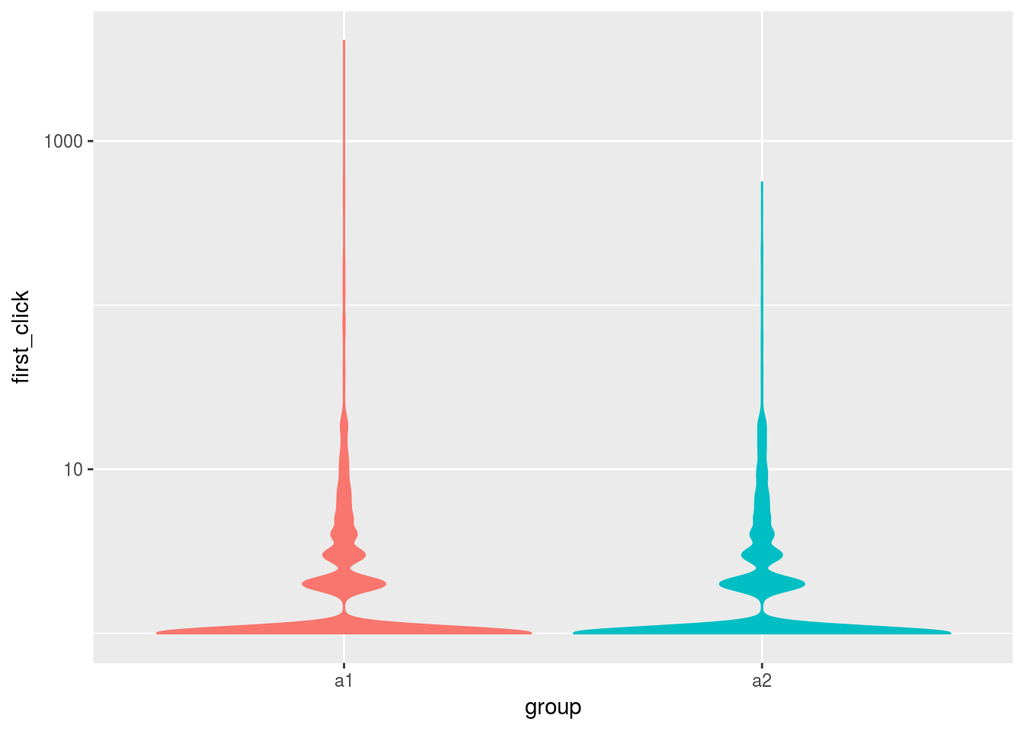

```r
grouped_data_a <- dados %>%
    filter(group == 'a')
grouped_data_a1 <- grouped_data_a[sample(1:nrow(grouped_data_a), 12000,
    replace=FALSE),]

grouped_data_a1$group <- 'a1'

grouped_data_a2 <- grouped_data_a[sample(1:nrow(grouped_data_a), 12000,
    replace=FALSE),]

grouped_data_a2$group <- 'a2'

grouped_data_a <- rbind(grouped_data_a1,grouped_data_a2)


grouped_data_a %>%
    ggplot(aes(x= group,
               y = first_click,
               color= group, fill = group)) +
    geom_violin() +
    theme(plot.title = element_text(hjust = 0.5), legend.position="none") + scale_y_log10()
```

Para o grupo a1 calculamos aqui a relação dele e sumarizamos os dados, tendo como consequência seu intervalo de confiança com 95% de confiabilidade.

```r
data_grouped_day_1 <- grouped_data_a1 %>%
    mutate(date = as.character.Date(floor_date(session_start_date, unit='day'))) %>%
    group_by(session_id) %>%
    summarise(
      group = Mode(group),
      date = last(date)
    ) %>%
    group_by(date) %>%
    count(date)

data_grouped_day_2 <- grouped_data_a1 %>%
    filter(num_clicks > 0) %>%
    mutate(date = floor_date(session_start_date, unit='day')) %>%
    group_by(session_id) %>%
    summarise(
      group = Mode(group),
      date = last(date)
    ) %>%
    group_by(date) %>%
   count(date)

data_ratio <- data.frame(data_grouped_day_1$date,  data_grouped_day_2$n / data_grouped_day_1$n )
data_ratio <- na.omit(data_ratio)
x <- c("date", "ratio")
colnames(data_ratio) <- x


df4 <- summarySE(data_ratio, measurevar="ratio",na.rm = TRUE, conf.interval=.95)

df4$N <- as.factor(df4$N)
df4
```

```
##    .id N     ratio         sd          se         ci
## 1 <NA> 8 0.3515751 0.02001547 0.007076536 0.01673335
```

Mesma coisa para o grupo a2.

```r
data_grouped_day_1 <- grouped_data_a2 %>%
    mutate(date = as.character.Date(floor_date(session_start_date, unit='day'))) %>%
    group_by(session_id) %>%
    summarise(
      group = Mode(group),
      date = last(date)
    ) %>%
    group_by(date) %>%
    count(date)

data_grouped_day_2 <- grouped_data_a2 %>%
    filter(num_clicks > 0) %>%
    mutate(date = floor_date(session_start_date, unit='day')) %>%
    group_by(session_id) %>%
    summarise(
      group = Mode(group),
      date = last(date)
    ) %>%
    group_by(date) %>%
   count(date)

data_ratio <- data.frame(data_grouped_day_1$date,  data_grouped_day_2$n / data_grouped_day_1$n )
data_ratio <- na.omit(data_ratio)
x <- c("date", "ratio")
colnames(data_ratio) <- x


df4 <- summarySE(data_ratio, measurevar="ratio",na.rm = TRUE, conf.interval=.95)

df4$N <- as.factor(df4$N)
df4
```

```
##    .id N     ratio         sd          se         ci
## 1 <NA> 8 0.3566008 0.01855467 0.006560067 0.01551209
```